# Empirical Research in Economics - Exercise 4

Student1 Tobias Lind Knudsen, Student1 Nr. 21-621-636

Student2 Alexandra Gort, Student2 Nr. 20-617-908

Student3 Olivier Benoit, Student3 Nr. 20-612-057

2023-04-18

# Part I: Descriptive Statistics

**(1) Construct two histograms representing the distribution of the average weekly wages in the first year after the experiment (i.e., the fourth year) for the treatment and control groups (EARNY4). Can anything be said about the effect of the program on the basis of these histograms?**

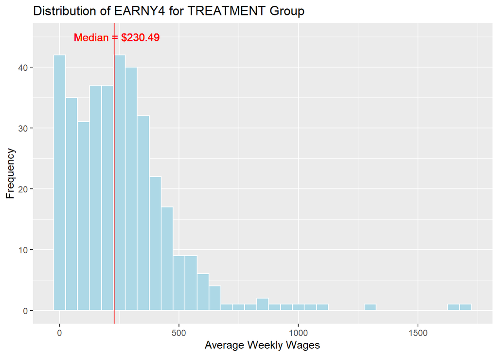

```r
# Construct two histograms and discuss the effect of the program
# Loading packages
library(ggplot2)
library(dplyr)

# Loading the data into a data frame
load("C:/Users/tobia/Desktop/University/University of St. Gallen/Semester 4/2. Data Analytics 2/R - Exercises/Data/eren_ozbeklik.RDATA")

wage_data <- data

# Cleaning the data
wage_data <- na.omit(wage_data)

# One histogram with breaks, the other the "normal" way
med_treat <- median(wage_data$EARNY4[wage_data$participation == 1])

wage_data %>%
  filter(participation == 1) %>%
  ggplot(aes(x = EARNY4)) +
  geom_histogram(binwidth = 50, color = "white", fill = "lightblue") +
    geom_vline(xintercept=med_treat, color="red") +
    annotate("text", x = med_treat + 10, y = 45, label = paste0("Median = $", round(med_treat, 2)), color = "red",
           data = filter(wage_data, participation == 1)) +
  labs(title = "Distribution of EARNY4 for TREATMENT Group", x = "Average Weekly Wages", y = "Frequency")
```

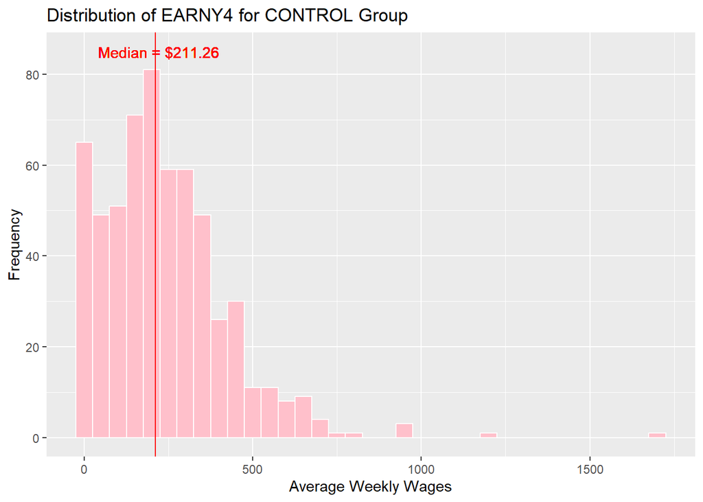

```r
# Plotting the second histogram
med_control <- median(wage_data$EARNY4[wage_data$participation == 0])

wage_data %>%
  filter(participation == 0) %>%
  ggplot(aes(x = EARNY4)) +
  geom_histogram(binwidth = 50, color = "white", fill = "pink") +
  geom_vline(xintercept=med_control, color="red") +
  annotate("text", x = med_control + 10, y = 85, label = paste0("Median = $", round(med_control, 2)), color = "red",
           data = filter(wage_data, participation == 0)) +
  labs(title = "Distribution of EARNY4 for CONTROL Group", x = "Average Weekly Wages", y = "Frequency")
```

**Here write your comment:** The median of the treatment group is indeed higher than the control group. Furthermore there are less people in the treatment group having no weekly income at all.

**(2) Are there differences in average weekly wages in the fourth year between individuals of different ethnicities? Are there differences in average weekly wages in the fourth year between individuals of different gender? If so, what might this mean for the effect of program participation?.**

```r
# HERE: Find out the differences in wages between race and gender
# Selecting different races and finding general stats about each wage rate
white_data <- wage_data %>%
  select(race_eth, EARNY4) %>%
  filter(race_eth == 1)

black_data <- wage_data %>%
  select(race_eth, EARNY4) %>%
  filter(race_eth == 2)

hispanic_data <- wage_data %>%
  select(race_eth, EARNY4) %>%
  filter(race_eth == 3)

indian_data <- wage_data %>%
  select(race_eth, EARNY4) %>%
  filter(race_eth == 4)

#White wage statistics
summary(white_data$EARNY4)
```

```
##    Min. 1st Qu.  Median    Mean 3rd Qu.    Max.
##     0.0   114.9   254.3   285.2   362.1  1696.7
```

```r
#Black wage statistics
summary(black_data$EARNY4)
```

```
##    Min. 1st Qu.  Median    Mean 3rd Qu.    Max.
##     0.0   101.5   205.8   224.3   305.6  1692.1
```

```r
#Hispanic wage statistics
summary(hispanic_data$EARNY4)
```

```
##    Min. 1st Qu.  Median    Mean 3rd Qu.    Max.
##     0.0   118.8   217.6   253.4   361.5   877.8
```

```r
#Indian wage statistics
summary(indian_data$EARNY4)
```

```
##    Min. 1st Qu.  Median    Mean 3rd Qu.    Max.
##     0.0   131.7   176.6   218.8   308.8   703.4
```

```r
# Selecting male and female genders and finding general stats about each wage rate
male_data <- wage_data %>%
  select(female, EARNY4) %>%
  filter(female == 0)

female_data <- wage_data %>%
  select(female, EARNY4) %>%
  filter(female == 1)

#Male wage statistics
summary(male_data$EARNY4)
```

```
##    Min. 1st Qu.  Median    Mean 3rd Qu.    Max.
##     0.0   121.9   243.7   276.0   374.0  1696.7
```

```r
#Female wage statistics
summary(female_data$EARNY4)
```

```
##    Min. 1st Qu.  Median    Mean 3rd Qu.    Max.
##    0.00   92.41  186.35  208.23  296.26 1193.62
```

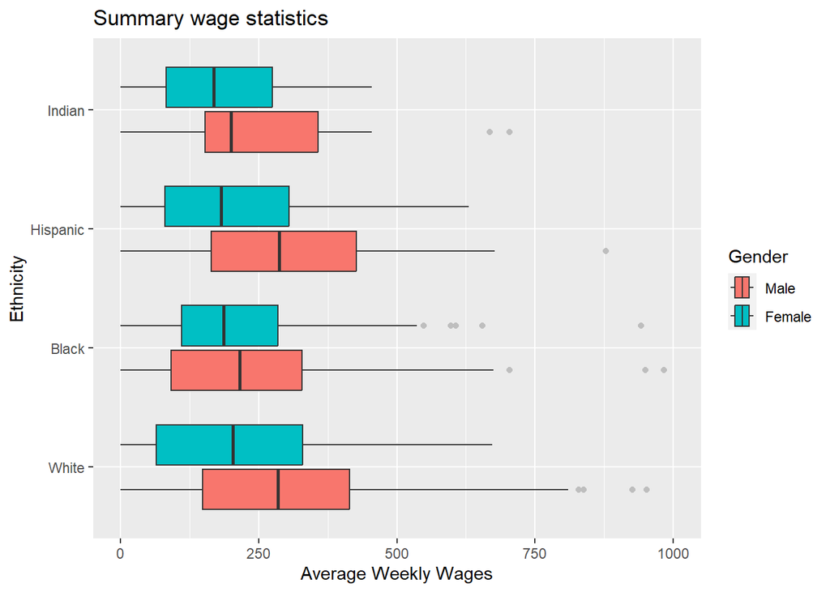

```r
# Turning gender and race variables into categorical values with labels instead
wage_data$race_eth <- factor(wage_data$race_eth, levels = c(1, 2, 3, 4), labels = c("White", "Black", "Hispanic", "Indian"))
wage_data$female <- factor(wage_data$female, levels = c(0, 1), labels = c("Male", "Female"))

# Plotting summary stats using boxplots
ggplot(wage_data, aes(EARNY4, race_eth, fill = female)) +
  geom_boxplot(outlier.colour = "grey") +
  scale_x_continuous(limits = c(0,1000)) +
  labs(x = "Average Weekly Wages", y = "Ethnicity", fill = "Gender", title = "Summary wage statistics")
```

**(3) What percentage of the treatment group actually participated in the program?**

```r
# Here: compute your code
participation <- wage_data %>%
  select(assignment, participation) %>%
  filter(assignment == 1) %>%
  group_by(participation) %>%
  count()

treatment_group <- participation[1,2] + participation[2,2]
paste("Number of people in treatment group: ", treatment_group)
```

```
## [1] "Number of people in treatment group:  474"
```

```r
paste("Number of people of treatment group that participated in the program: ", participation[2,2])
```

```
## [1] "Number of people of treatment group that participated in the program:  371"
```

```r
par_percent <- participation[2,2] / treatment_group
paste("Therefore, the participation percentage is:", round(par_percent, 4) * 100, "%")
```

```
## [1] "Therefore, the participation percentage is: 78.27 %"
```

**Here write your comment:**

Only 78% actually participated in the program, not every single person in the treatment group.